# Final

Gabriel Garcia-Ruiz, 917320019

2023-06-10

# Final

## Abstract

This data science project aims to predict the the outcome of a feedback variable. We will use a subset of a larger data set. This subset is of mice whose neuro-activty was recorded by various metrics. The primary objective is to build a prediction model that can accurately predict the outcome of a feedback variable.

We begin by performing exploratory data analysis to gain a better understanding of the data we are working with. We seek to identify patterns in the to motivate our data integration and model.

Data integration involves constructing our own data frame from the original data set that is useful to conduct statistical analysis. This is important given the complexity of the original data set, it is difficult to work with directly.

Finally, when we have constructed a useful data frame we will build a prediction model using logistic regression. The main performance metric is accuracy. We want to predict the outcome variable on a hand-picked subset, our data frame, and using hand-picked prediction variables from our exploratory analysis.

## Introduction

We will analyze the study conducted by Steinmetz et al. (2019). Our focus is on subset of their experiments on 4 of the 10 mice and 18 of the 39 sessions. Each session is composed of hundreds of trials where visual stimuli were presented to the mice. The stimuli were contrast level differences between a left and right panel, with 4 levels of contrast. If the mouse correctly identified which side had a lower contrast, the trial was a success. Success (or feedback type) therefore was binary variables either (1) for success or (-1) for failure. A reward was given for a successful trial.

The data structure given is 18 RDS files for each session. Each session includes the variables: contrast_left, contrast_right, feedback_type, mouse_name, brain_area, date_exp, and spks and time. Contrast left and contrast right take on one of the four contrast values described before (0, 0.25, 0.5, 1). brain_area refers to the brain area where neural activity took place. date_exp is the date the experiment took place. spks is a list of matrices where the rows of the matrices are neurons and the columns are time bins. Time is a list of the times neural activity took place.

The objective of this project is to use the aforementioned data set to build a prediction model for feedback types (feedback_type). This will include preliminary, exploratory dat analysis, to get to observe potential patterns in the data. Then we perform data integration by combining the data in from all 18 session into a data frame of useful variables (removing not useful ones). Our prediction model will be based on our initial data analysis and will use our newly constructed data frame to perform logistic regression. The model selection will be analyzed by tweaking the model for optimality. Performance will be judged by accuracy, recall, and F1 score.

## Data Exploration

### i

The following is a table of summary statistics for the data set. Note: n_brain_areas is the number of brain areas that we engaged in a session, and success_rate is the percentage of positive feedback types there were in a session.

Table 1 : Session Information

| mouse_name | date_exp | n_brain_area | n_neurons | n_trials | success_rate |
| --- | --- | --- | --- | --- | --- |
| Cori | 2016-12-14 | 8 | 734 | 114 | 0.6052632 |
| Cori | 2016-12-17 | 5 | 1070 | 251 | 0.6334661 |
| Cori | 2016-12-18 | 11 | 619 | 228 | 0.6622807 |
| Forssmann | 2017-11-01 | 11 | 1769 | 249 | 0.6666667 |
| Forssmann | 2017-11-02 | 10 | 1077 | 254 | 0.6614173 |
| Forssmann | 2017-11-04 | 5 | 1169 | 290 | 0.7413793 |
| Forssmann | 2017-11-05 | 8 | 584 | 252 | 0.6706349 |
| Hench | 2017-06-15 | 15 | 1157 | 250 | 0.6440000 |
| Hench | 2017-06-16 | 12 | 788 | 372 | 0.6854839 |
| Hench | 2017-06-17 | 13 | 1172 | 447 | 0.6196868 |
| Hench | 2017-06-18 | 6 | 857 | 342 | 0.7953216 |
| Lederberg | 2017-12-05 | 12 | 698 | 340 | 0.7382353 |
| Lederberg | 2017-12-06 | 15 | 983 | 300 | 0.7966667 |
| Lederberg | 2017-12-07 | 10 | 756 | 268 | 0.6940299 |
| Lederberg | 2017-12-08 | 8 | 743 | 404 | 0.7648515 |
| Lederberg | 2017-12-09 | 6 | 474 | 280 | 0.7178571 |
| Lederberg | 2017-12-10 | 6 | 565 | 224 | 0.8303571 |
| Lederberg | 2017-12-11 | 10 | 1090 | 216 | 0.8055556 |

This table provides a concise summary of some of the most significant variables in the data set. Below is a summary of the statistics included in the table.

```
##   mouse_name          date_exp          n_brain_area     n_neurons
##  Length:18          Length:18          Min.   : 5.00   Min.   : 474.0
##  Class :character   Class :character   1st Qu.: 6.50   1st Qu.: 707.0
##  Mode  :character   Mode  :character   Median :10.00   Median : 822.5
##                                        Mean   : 9.50   Mean   : 905.8
##                                        3rd Qu.:11.75   3rd Qu.:1086.8
##                                        Max.   :15.00   Max.   :1769.0
##     n_trials      success_rate
##  Min.   :114.0   Min.   :0.6053
##  1st Qu.:249.2   1st Qu.:0.6616
##  Median :261.0   Median :0.6898
##  Mean   :282.3   Mean   :0.7074
##  3rd Qu.:330.0   3rd Qu.:0.7590
##  Max.   :447.0   Max.   :0.8304
```

## ii

The following is a rastor plot of neural activity from a single trial. A rastor plot shows the timing and pattern of neuron activity.

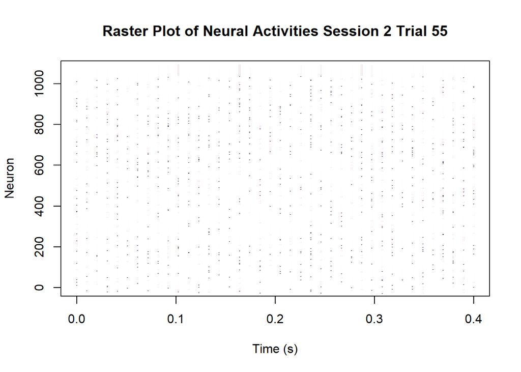

Analyzing many of these plots tells me that neuron activity is remains uniformly distributed across time. There doesn’t appear to be a particular pattern to neuron activity over time.

### iii

The following is histogram that displays the spike count of trials over a session. Spike count is defined as the the total number of times the neurons in a trial sent a signal.

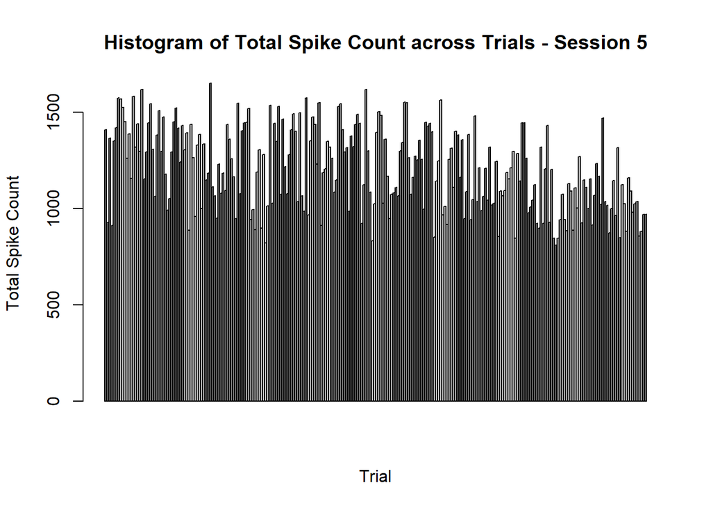

### iv

K-means clustering:

I perform k-means clustering on all of the sessions to get an idea of how the sessions may be related. I chose to use four clusters because their were four mice, and there might have been some correlation between their sessions.

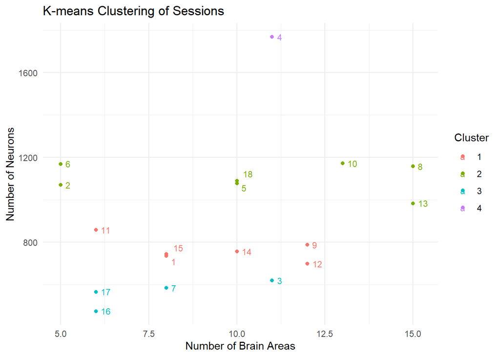

This graph of the clustering of session shows me which sessions are most closely related to each other. I note that sessions 2, 5, and 15 are closest to sessions 1 and 18, which is where our later test data will come from.

## Data Integration

### i/ii

To perform data integration I will bring together all of the useful variables i have observed across all sessions into a data frame with a row for every trial in every session and 9 variables. The variables are mouse_name, date_exp, session_id, n_brain_areas, n_neurons, n_trials, success_rate, normalized_spike_counts, and feedback_type. The key step I took in this process was normalizing the spike count variable using min-max normalization, because I noticed how widely this variable varied.

Having performed this integration I now use it create some more useful figures:

The following is histogram of brain areas by average spike count.

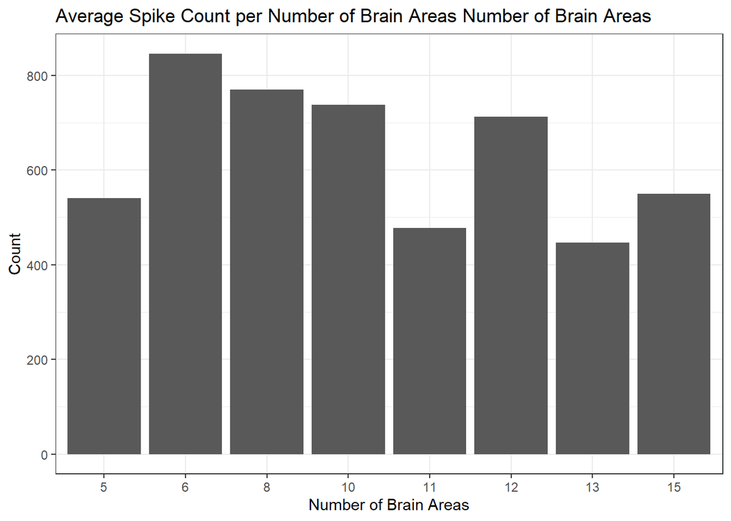

The number of brain areas engaged seems important for determining th total spike count.

The following is a heat map of feedback types according to normalized spike counts and session index.

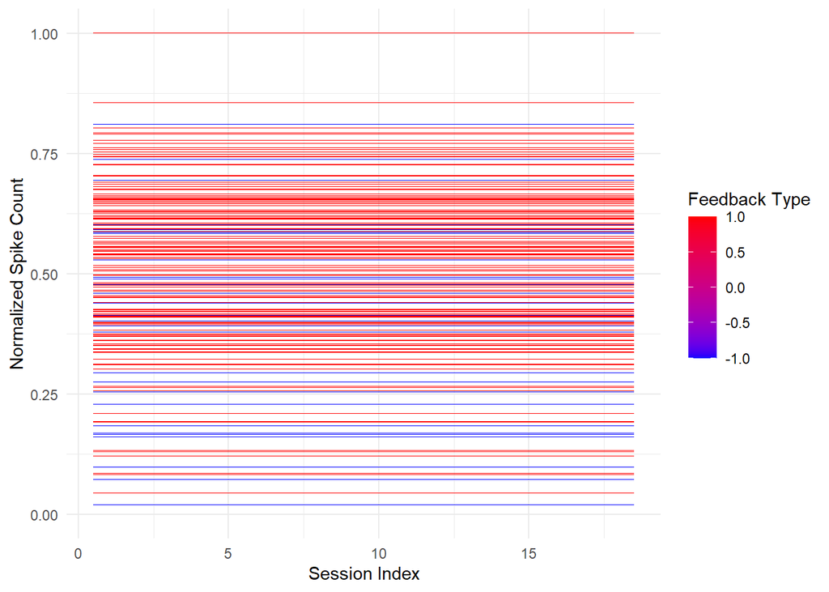

The following is a box plot for success rates for each mouse.

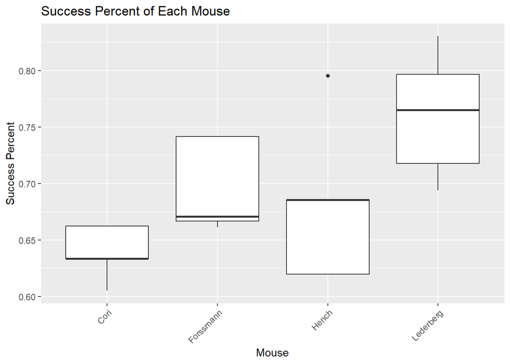

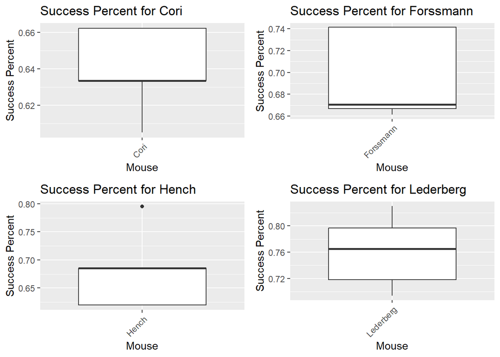

## Predictive Modeling

Using the data frame I constructed I’m now ready to build a prediction model for feedback types.

The following is a mathematical representation of the logistic regression model I implement.

Let $Y$ represent the target variable (feedback type) and $X$ represent the predictors (number of brain areas, number of neurons, success rate, and normalized spike counts).

The logistic regression model can be written as:

$$\text{{logit}}(P(Y = 1)) = \beta_0 + \beta_1 \cdot
\text{{n\_brain\_area}} + \beta_2 \cdot \text{{n\_neurons}} + \beta_3
\cdot \text{{success\_rate}} + \beta_4 \cdot
\text{{normalized\_spk\_counts}}$$

where: - $P(Y = 1)$ is the probability of the target variable being equal to 1 (positive class). - $\text{{logit}}(p)$ is the log-odds function defined as $\text{{logit}}(p) = \log\left(\frac{p}{1-p}\right)$. - $\beta_0$ is the intercept or bias term. - $\beta_1, \beta_2, \beta_3, \beta_4$ are the coefficients associated with each predictor variable.

The logistic regression model is fitted using the training data with the `glm()` function in R, specifying the family as binomial and the link function as the logit link function.

Note: I have limited the sessions I use to train my model to sessions 2, 5, 11, and 15. These are the session I observed through my exploratory analysis and data integration to be most similar to sessions 1 and 18.

## Prediction Performance

The following is the output of the confusion matrix of the prediction model.

```
## Confusion Matrix and Statistics
##
##           Reference
## Prediction  -1   1
##         -1   0   0
##         1   54 143
##
##                Accuracy : 0.7259
##                  95% CI : (0.658, 0.7869)
##     No Information Rate : 0.7259
##     P-Value [Acc > NIR] : 0.5366
##
##                   Kappa : 0
##
##  Mcnemar's Test P-Value : 5.498e-13
##
##             Sensitivity : 0.0000
##             Specificity : 1.0000
##          Pos Pred Value :    NaN
##          Neg Pred Value : 0.7259
##              Prevalence : 0.2741
##          Detection Rate : 0.0000
##    Detection Prevalence : 0.0000
##       Balanced Accuracy : 0.5000
##
##        'Positive' Class : -1
##
```

```
## Accuracy: 0.7258883
```

```
## Precision: NaN
```

```
## Recall: 0
```

```
## F1-score: NA
```

The following is a typical accuracy result when attempting to implement L1-regularization.

```
## [1] "Accuracy on Test Set Using L1 regularization: 37.845"
```

Note the much lower accuracy. I found through much trial and error that the optimal alpha value for L1_regularization is 0. Which is the same as simple logistic regression. Which is what I chosen to stick with.

### Discussion

In this project we aimed to investigate the relationship between key factors and the success rate of mice performing a neural decoding task.

Our results yielded several interesting results. I observed that changes over the short time frame each trial is conducted in held uniform distribution of neural activity, making it an unlikely source for model training. However, the neural spike count varied much across session and thus led me to believe that it was a good variable to account for in prediction modeling. Using k-means clustering also showed how closely related some sessions are when account for key factors like number of brain areas engaged.

These findings motivated which variables I chose to include in my home-made date frame. And once this data frame was made I was able to see visualize more relationships between variables. this further informed how I would build my prediction model.

Namely, the number of neurons, number of brain areas, success percentage, and normalized spike count, were the variables I found most promising for prediction modeling. I used them to build a logistic regression model that that attempted to improve via L1-regularization. I found the alpha equal to 0 (regular logistic regression), turned out be the optimal model for the best accuracy.

These findings contribute to a better understanding of how neural activity plays a part in how successful we may be at performing a brain-heavy task.